# Machine learning in epidemiology

Javier Garcia-Bernardo

2022-06-11

# Machine learning instead of traditional statistics

We will explore the difference in results using LASSO and using XGBoost. In XGBoost, we will use permutation feature importance to understand the contribution of the features (independent variables) to the model.

You can download the code [here](https://github.com/jgarciab/ml_julius) to run it on your computer.

### Set up libraries

```r
library(tidyverse) # Data manipulation
library(DT) # Print nice tables
library(caret) # Machine learning
library(glmnet) # LASSO
library(iml) # Interpretable AI
library(doParallel) # Run code in parrenallel

# Create the cluster (disable if this doesn't work on your computer). Make sure to run the last cell of this notebook at the end of the practical to stop the cluster!
cl <- makePSOCKcluster(5)
registerDoParallel(cl)
```

```r
create_data <- function(order, n_features = 100, n_obs = 1000) {
  # Set seed for replicability
  set.seed(0)

  # Create data: 100 features, mean = 3, sd = 1
  data <- matrix(3+rnorm(n_features*n_obs, 0, 1), ncol = n_features)

  # Convert to tibble
  colnames(data) <- paste0("V", 1:n_features)
  data <- as_tibble(data)

  # Add a few categorical variable
  data$cat1 <- sample(0:1, n_obs, replace = TRUE)
  data$cat2 <- sample(0:1, n_obs, replace = TRUE)
  data$cat3 <- sample(0:1, n_obs, replace = TRUE)
  data$cat4 <- sample(0:1, n_obs, replace = TRUE)
  data$cat5 <- sample(0:1, n_obs, replace = TRUE)

  # Create the response, which is the product of the first "order" features if cat1 == 0, and -1*product if cat1 == 1. Some noise is added
  # After running the code, you can modify this
  values <- pmap_dbl(data[, 1:order], prod)# data$V1*data$V2*data$V3...

  data$y <- 1*(data$cat1==0)*values  - 1*(data$cat1==1)*values + rnorm(n_obs, 0, 1)/10

  return(data)
}
```

## Create data

```r
# Create the data using a third-order interaction
data <- create_data(3, n_features = 100, n_obs = 1000)
# Independent variables
x_data <- as.matrix(data %>% dplyr::select(-y))
# dependent variable
y_data <- data$y
```

|  | V1 | V2 | V3 | V4 | V5 | V6 | V7 | V8 | V9 | V10 | V11 | V12 | V13 | V14 | V15 | V16 | V17 | V18 | V19 | V20 | V21 | V22 | V23 | V24 | V25 | V26 | V27 | V28 | V29 | … |
| --- | --- | --- | --- | --- | --- | --- | --- | --- | --- | --- | --- | --- | --- | --- | --- | --- | --- | --- | --- | --- | --- | --- | --- | --- | --- | --- | --- | --- | --- | --- |
| 1 | 4.263 | 2.713 | 3.444 | 2.462 | 3.793 | 3.393 | 2.579 | 3.592 | 3.228 | 1.745 | 1.78 | 2.994 | 2.802 | 3.48 | 4.271 | 2.591 | 4.339 | 1.922 | 3.34 | 5.113 | 2.471 | 2.897 | 2.458 | 1.887 | 0.964 | 3.314 | 3.663 | 4.309 | 1.62 | … |
| 2 | 2.674 | 4.841 | 3.012 | 3.497 | 1.863 | 3.458 | 1.729 | 2.866 | 4.945 | 1.572 | 1.799 | 2.079 | 3.15 | 1.61 | 2.545 | 1.924 | 4.14 | 4.393 | 2.813 | 2.762 | 3.133 | 3.623 | 3.627 | 3.51 | 3.629 | 3.526 | 2.502 | 2.578 | 3.716 | … |
| 3 | 4.33 | 2.843 | 2.991 | 1.558 | 2.798 | 1.78 | 3.839 | 3.887 | 0.959 | 4.003 | 2.504 | 2.879 | 2.079 | 3.461 | 3.532 | 3.852 | 2.853 | 4.273 | 3.379 | 6.073 | 2.728 | 4.569 | 2.931 | 2.454 | 1.726 | 1.82 | 3.268 | 2.524 | 2.415 | … |
| 4 | 4.272 | 1.61 | 2.698 | 1.887 | 1.978 | 1.878 | 3.54 | 2.71 | 3.175 | 3.028 | 3.067 | 0.884 | 2.405 | 2.942 | 3.493 | 4.118 | 3.961 | 3.724 | 2.707 | 2.855 | 3.643 | 4.195 | 0.614 | 0.787 | 2.47 | 1.372 | 1.847 | 3.424 | 3.51 | … |
| 5 | 3.415 | 1.527 | 3.492 | 1.985 | 2.176 | 3.993 | 4.868 | 3.567 | 3.149 | 2.334 | 2.943 | 2.002 | 1.983 | 4.024 | 2.453 | 3.921 | 1.609 | 4.019 | 1.645 | 3.665 | 3.998 | 2.184 | 3.744 | 3.864 | 1.602 | 2.902 | 4.344 | 2.91 | 5.074 | … |
| 6 | 1.46 | 2.93 | 2.397 | 3.567 | 3.241 | 1.167 | 3.445 | 2.276 | 4.573 | 2.024 | 3.256 | 3.634 | 3.589 | 4.072 | 3.524 | 3.177 | 3.589 | 2.311 | 3.997 | 2.28 | 1.9 | 3.431 | 2.466 | 1.681 | 3.019 | 3.913 | 3.709 | 2.808 | 3.92 | … |

## Method 1: Penalized regression (LASSO)

### Hyperparameter tuning using cross-validation (glmnet package)

We want to have a balance between flexibility and overfitting. In LASSO regression this is achieved by forcing the absolute sum of coeficients to be lower than a value. This is achieved with the parameter $\lambda$ (Higher $\lambda$ equals lower sum of coeficients)

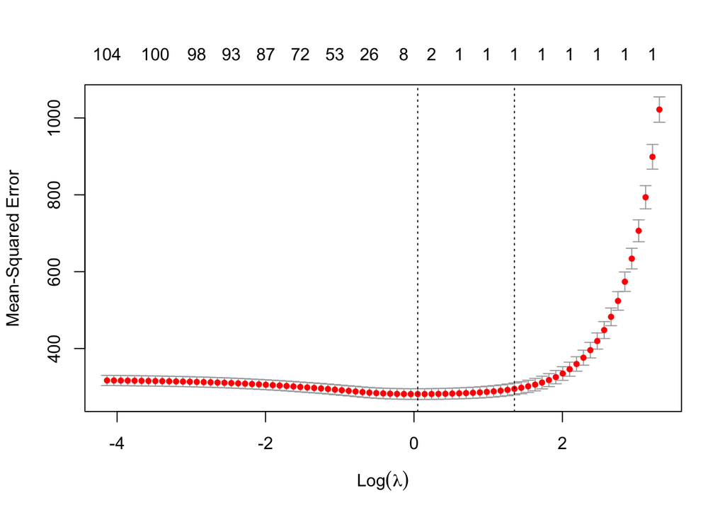

```r
# Find best regularization using cross-validation
# alpha = 1 --> LASSO. alpha = 0 --> Ridge
cvfit <- cv.glmnet(x = x_data, y = y_data, alpha = 1)

# x axis = lambda, y axis = error; top numbers = number of variables included in the model
plot(cvfit)
```

```r
# The best regularization (s="lambda.min")
coefs <- coef(cvfit, s = "lambda.min")
rownames(coefs)[coefs[,1]!= 0]
```

```
## [1] "(Intercept)" "V52"         "V64"         "V81"         "cat1"
```

```r
coefs[which(coefs!=0)]
```

```
## [1]  26.19700478  -0.15404352   0.27429164   0.09612859 -52.54800156
```

### Hyperparameter tuning using cross-validation (caret package)

```r
# Repeat 10 times the 5-fold cross validations
trctrl <- trainControl(method = "repeatedcv", number = 5, repeats = 10)

# Parameters to test (lambda = regularization parameter, LASSO (alpha = 1))
tune_grid <- expand.grid(lambda   = c(0, 0.0001, 0.001, 0.01, 0.05, 0.1, 1),
                         alpha = c(1))

# Test parameters using cross-validatoin
mod_glm <- caret::train(x = x_data, y = y_data,
                method = "glmnet",
                metric = "RMSE",
                trControl=trctrl,
                tuneGrid = tune_grid,
                tuneLength = 10,
                verbosity = 0)

# Show the model
mod_glm
```

```
## glmnet
##
## 1000 samples
##  105 predictor
##
## No pre-processing
## Resampling: Cross-Validated (5 fold, repeated 10 times)
## Summary of sample sizes: 800, 800, 800, 800, 800, 800, ...
## Resampling results across tuning parameters:
##
##   lambda  RMSE      Rsquared   MAE
##   0e+00   18.02972  0.6858138  14.11509
##   1e-04   18.02972  0.6858138  14.11509
##   1e-03   18.02972  0.6858138  14.11509
##   1e-02   18.02972  0.6858138  14.11509
##   5e-02   17.90691  0.6896343  14.01403
##   1e-01   17.74913  0.6945809  13.88257
##   1e+00   16.77218  0.7274510  13.01915
##
## Tuning parameter 'alpha' was held constant at a value of 1
## RMSE was used to select the optimal model using the smallest value.
## The final values used for the model were alpha = 1 and lambda = 1.
```

```r
# Print the coefficients of the best model
coefs <- coef(mod_glm$finalModel, mod_glm$bestTune$lambda)
rownames(coefs)[coefs[,1]!= 0]
```

```
## [1] "(Intercept)" "V52"         "V64"         "V81"         "V95"
## [6] "cat1"
```

```r
coefs[which(coefs!=0)]
```

```
## [1]  26.14239811  -0.20590818   0.33000864   0.15003334  -0.02244794
## [6] -52.64642463
```

## Method 2: XGBoost

### Prevent overfitting: Hyperparameter tuning caret

XGBoost has many different paramters, including the number of number of trees (nrounds), depth of trees (max_depth), minimum reduction in the loss to make a further partition (gamma), fraction of samples used to train the tree (subsample), the fraction of features (randomly selected) that will be used to train each tree (colsample_bytree).

We will use CV to find the best ensampble for our application.

Note that this takes a lot longer than in LASSO regression (mainly because we have many combinations of parameters to test)

```r
# Training using cross-validation (5-fold)
trctrl <- trainControl(method = "repeatedcv", number = 5, repeats = 5)

# Parameters to test (XGBoosting has a lot of things you can tweak)
tune_grid <- expand.grid(nrounds=c(10,30,100,200),
                         max_depth = c(3:6),
                         eta = c(0.05),
                         gamma = c(0.01),
                         colsample_bytree = c(0.5),
                         subsample = c(0.5),
                         min_child_weight = c(0))

# Test parameters using cross-validatoin
mod_xgb <- caret::train(x = x_data, y = y_data,
                method = "xgbTree",
                trControl=trctrl,
                tuneGrid = tune_grid,
                tuneLength = 10,
                verbosity = 0)

# Show the model
mod_xgb
```

[output not shown]

### Interpretability: Permutation importance

Note: Ideally you want to do this in a different dataset. This can be done for example by dividing your original dataset in two parts, the training dataset (used for hyperparameter tuning), and a test dataset (used to evaluate feature importance).

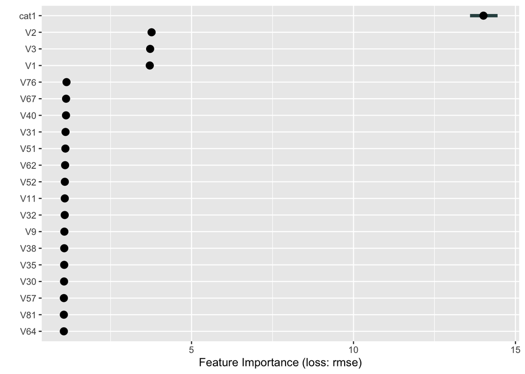

```r
# Create predictor to interpret
mod <- Predictor$new(mod_xgb,
                     data = as_tibble(x_data),
                     y = y_data,
                     predict.function = predict)

# Calculate permutation importance, plot the ratio of new_error/original_error
new <- FeatureImp$new(
  mod,
  loss = "rmse",
  compare = "ratio",
  n.repetitions = 20,
  features = NULL #all features
)

# show only the top 20 variables (out of 100 features)
new$results <- head(new$results, 20)

# Plot
plot(new)
```

#### Show everything except the first (which should be cat1)

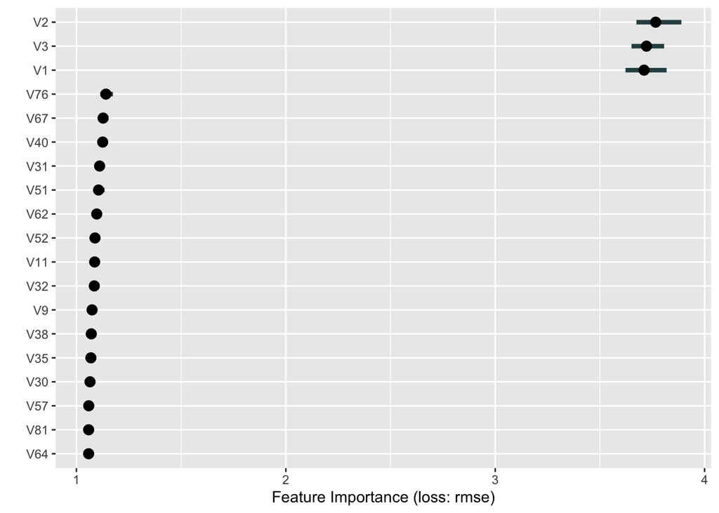

```r
# show only the top 20 variables (out of 100 features)
new$results <- tail(new$results, 19)

# Plot
plot(new)
```

## Clean up

```r
# stop the process cluster
stopCluster(cl)
```